# Chapters 6 & 7: TD Learning and n-step Bootstrapping

3 July 2020

## Questions:

1. The book book mentions at the very end of Chapter 6 that TD methods are being used to explore things like weather patterns and animal behavior. I'm especially interested in these sorts of scientific applications. What resource would be a good place to learn more about this side of RL?
1. The only difference between SARSA, Q-Learning and Expected SARSA is the target for updates. Are there other targets worth exploring? For example, I can imagine generalizing Q-learning to target some percentile of the distribution of returns instead of targeting the maximum. I'm not sure if there would ever be a reason to do such a thing.
1. It appears that Expected SARSA flew under-the-radar as a homework exercise for 20 years before van Seijen et al wrote a well-regarded paper. Is this book still close enough to the frontiers of RL that spending enough time with the homework exercises might lead to a paper?
1. Is OpenAI Gym really used in research?

## Experiments

I thought the "CliffWorld" example from page 132 was especially interesting. It does a great job showing the difference between the outcome of SARSA and Q-learning. I repeated that experiment below.

I kept the code implementing the agents and environments in seperate files, and only the evaluation logic is in this notebook.

```python
import matplotlib.pyplot as plt
import numpy as np
from tqdm import tqdm
from agent import Q_Agent, SARSA_Agent, run_agent
from env import GridWorld, CliffWorld
```

### GridWorld

To help make sure I implemented Q-learning and SARSA correctly, I evaluated them using the GridWorld example from the lectures.

#### Q-Learning

```python
# Q-agent
agent = Q_Agent(13, 3, epsilon=0.5, lr=0.1)
env = GridWorld()

rewards = run_agent(env, agent, 1000)
```

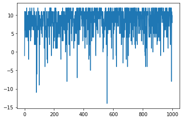

```python
plt.plot(rewards)
plt.show()
```

The agent is more likely to explore the optimal path (with return 12) as more episodes are evaluated. Furthermore, it does indeed find the optimal deterministic policy, as shown below.

```python
rewards = run_agent(env, agent.learned_policy(), 10)
```

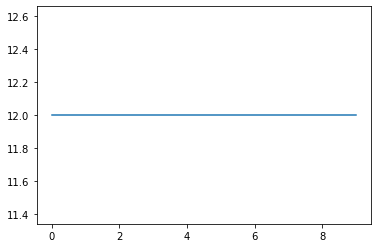

```python
plt.plot(rewards)
plt.show()
```

#### SARSA

Results for SARSA are similar to Q-learning for this GridWorld.

```python
agent = SARSA_Agent(13, 3, epsilon=0.5, lr=0.1)
env = GridWorld()

rewards = run_agent(env, agent, 1000)
```

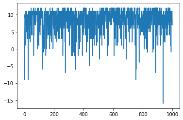

```python
plt.plot(rewards)
plt.show()
```

```python
rewards = run_agent(env, agent.learned_policy(), 10)
```

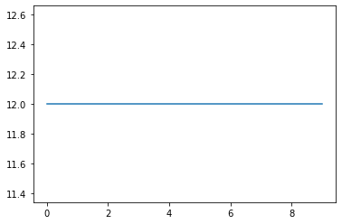

```python
plt.plot(rewards)
plt.show()
```

# Cliffworld

Adapted from Example 6.6 on pg 132.

```python
q_agent = Q_Agent(38, 4, epsilon=0.1, lr=0.05)
sarsa_agent = SARSA_Agent(38, 4, epsilon=0.1, lr=0.05)
env = CliffWorld()

epochs = 100
q_returns = np.zeros([epochs,500])
sarsa_returns = np.zeros([epochs,500])
for i in tqdm(range(epochs)):
    q_returns[i] = run_agent(env, q_agent, 500)
    sarsa_returns[i] = run_agent(env, sarsa_agent, 500)
```

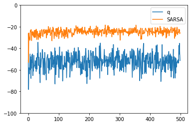

```python
plt.plot(q_returns.mean(axis=0), label="q")
plt.plot(sarsa_returns.mean(axis=0), label="SARSA")
plt.ylim(-100,0)
plt.legend()
```

SARSA performs better than Q-Learning while training since SARSA takes into account possible penalties from exploration. However, Q Learning will ultimately find the optimal policy while SARSA does not.

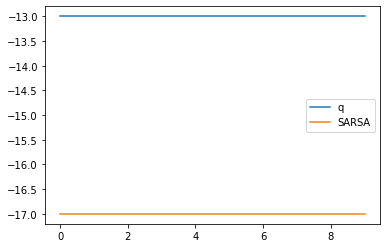

```python
plt.plot(run_agent(env, q_agent.learned_policy(), 10), label="q")
plt.plot(run_agent(env, sarsa_agent.learned_policy(), 10), label="SARSA")
plt.legend()
```